# Practical Machine Learning, Project July ‘15

Kate Sergeeva

## Project summary

The goal of this project is using machine learning techniques to find a best model which will be able to predict how good athletes are doing the particular types of exercises and helps to catch the common mistakes.

Data for this project kindly provided by a group of enthusiasts who take measurements about themselves regularly using devices such as Jawbone Up, Nike FuelBand, and Fitbit to find patterns in their behavior to improve their health.

We will use data from accelerometers on the belt, forearm, arm, and dumbell of 6 participants. They were asked to perform barbell lifts correctly and incorrectly in 5 different ways.

*More information is available from the website here: http://groupware.les.inf.puc-rio.br/har (see the section on the Weight Lifting Exercise Dataset).*

Project report will describe the following: - how the model was built, - how the cross-validation was used, - how out of sample error was estimated, - how other choices been made.

## Contents

- Loading and cleansing data
- Building models
- Cross-validation to measure “out of sample error”
- Model selection
- Report the results of test cases processing

## Loading and cleansing data

The data downloaded from the website http://groupware.les.inf.puc-rio.br/har - Human Activity Recognition -> Weight Lifting Exercises Dataset.

Summary of loaded data provided in the appendix of this document.

### Removing meaningless variables

The test cases require predictions for particular moments with no connections to the style of particular athlet and it allows us to simply exclude from the following consideration the name of athlet and any time series data and row numbers.

```r
modelTrain <- subset(train, select = -c(user_name, raw_timestamp_part_1, raw_timestamp_part_2,
                                        cvtd_timestamp, new_window, num_window, X))
```

### Handling missing values

Closer look to the data showed that it contains some inappropriate symbols and true missing values, that is need to be handled of using replacement and imputing techniques.

```r
modelTrain[modelTrain == ""] <- NA
#looks like data comes from the Excel or similar editor and contains such a nice
modelTrain[modelTrain == "#DIV/0!"] <- NA

# Lookup for NA columns
naVars <- data.frame(apply(modelTrain, 2, function(x) {sum(is.na(x))}))
naVars$toRemove <- apply(naVars, 1, function(y) {y == length(modelTrain[, 1])})
columnsToExclude <- rownames(naVars[naVars$toRemove == "TRUE", ])
```

Columns to exclude due to emptiness.

```r
columnsToExclude
```

```
## [1] "kurtosis_yaw_belt"     "skewness_yaw_belt"     "kurtosis_yaw_dumbbell"
## [4] "skewness_yaw_dumbbell" "kurtosis_yaw_forearm"  "skewness_yaw_forearm"
```

```r
dim(modelTrain)
```

```
## [1] 19622   147
```

### Make up column classes

Before any modeling it is a good idea to check the variables classes and make sure that thea are all have the correct data type.

```r
# Convert character columns into numeric
library(taRifx)
modelTrain <- japply(modelTrain, which(sapply(modelTrain, class)=="character"),as.integer)
modelTrain <- japply(modelTrain, which(sapply(modelTrain, class)=="integer"),as.integer)
modelTrain <- japply(modelTrain, which(sapply(modelTrain, class)=="factor"),as.integer)

# Convert classe to factor
modelTrain$classe <- as.factor(modelTrain$classe)
```

### Tricky moment

Current number of variables most likely will cause the very long executing process and it would be better to reduce some dimensions. For example, instead of using nearZeroVar function I decided to play with lucky “cut-off” around number of missing values in the “nothing to impute about” columns.

```r
library(e1071)
dim(modelTrain)
```

```
## [1] 19622   147
```

```r
modelTrain[is.na(modelTrain)] <- 0
colAn <- data.frame(colSums(subset(modelTrain, select = -classe) == 0))
modelTrain <- modelTrain[, - which(colAn[, 1] > 19000)]
dim(modelTrain)
```

```
## [1] 19622    53
```

Now we have ready to modeling clean and nice data set with a manageable number of predictors.

## Building models

Before going deep into modeling better previously to take care of possible ways of improving productivity of your computer and use parallel processing if it is possible.

```r
# Do parallel
library(doParallel)
registerDoParallel(cores=4)
```

### Subsetting data for cross-validation

The idea of cross-validation is very nice and undoubtedly useful - to split data into two separated parts (around 70/30), learn the model at the biggest one and than estimate the out of sample error on the smallest one. The idea might be complicated with number of splits and their usage, but in case of our pretty huge data set with the managable amount of predictors I will follow of idea of just two random splits.

```r
library(caret)
inTrain <- createDataPartition(y = modelTrain$classe, p = 0.7, list = FALSE)
training <- modelTrain[inTrain, ]
testing <- modelTrain[-inTrain, ]
dim(training); dim(testing)
```

```
## [1] 13737    53
```

```
## [1] 5885   53
```

### Modeling

```r
library(caret)
library(randomForest)
library(rattle)
```

Building and validating predictability of the rpart model.

```r
modelRPART <- train(classe ~ ., method = "rpart",
                    data = training,  na.action = na.pass)
print(modelRPART$finalModel)
```

```
## n= 13737
##
## node), split, n, loss, yval, (yprob)
##       * denotes terminal node
##
##  1) root 13737 9831 1 (0.28 0.19 0.17 0.16 0.18)
##    2) roll_belt< 130.5 12596 8701 1 (0.31 0.21 0.19 0.18 0.11)
##      4) pitch_forearm< -33.95 1093    6 1 (0.99 0.0055 0 0 0) *
##      5) pitch_forearm>=-33.95 11503 8695 1 (0.24 0.23 0.21 0.2 0.12)
##       10) magnet_dumbbell_y< 438.5 9722 6976 1 (0.28 0.18 0.24 0.19 0.11)
##         20) roll_forearm< 122.5 6075 3611 1 (0.41 0.18 0.18 0.17 0.062) *
##         21) roll_forearm>=122.5 3647 2445 3 (0.077 0.18 0.33 0.22 0.19) *
##       11) magnet_dumbbell_y>=438.5 1781  880 2 (0.035 0.51 0.043 0.23 0.19) *
##    3) roll_belt>=130.5 1141   11 5 (0.0096 0 0 0 0.99) *
```

```r
predRPART <- predict(modelRPART, subset(testing, select = -classe))
confusionMatrix(predRPART, testing$classe)
```

```
## Confusion Matrix and Statistics
##
##           Reference
## Prediction    1    2    3    4    5
##          1 1520  460  468  407  149
##          2   25  392   32  164  157
##          3  126  287  526  393  275
##          4    0    0    0    0    0
##          5    3    0    0    0  501
##
## Overall Statistics
##
##                Accuracy : 0.4994
##                  95% CI : (0.4865, 0.5123)
##     No Information Rate : 0.2845
##     P-Value [Acc > NIR] : < 2.2e-16
##
##                   Kappa : 0.3466
##  Mcnemar's Test P-Value : NA
##
## Statistics by Class:
##
##                      Class: 1 Class: 2 Class: 3 Class: 4 Class: 5
## Sensitivity            0.9080  0.34416  0.51267   0.0000  0.46303
## Specificity            0.6476  0.92035  0.77753   1.0000  0.99938
## Pos Pred Value         0.5060  0.50909  0.32732      NaN  0.99405
## Neg Pred Value         0.9465  0.85396  0.88312   0.8362  0.89203
## Prevalence             0.2845  0.19354  0.17434   0.1638  0.18386
## Detection Rate         0.2583  0.06661  0.08938   0.0000  0.08513
## Detection Prevalence   0.5105  0.13084  0.27307   0.0000  0.08564
## Balanced Accuracy      0.7778  0.63226  0.64510   0.5000  0.73120
```

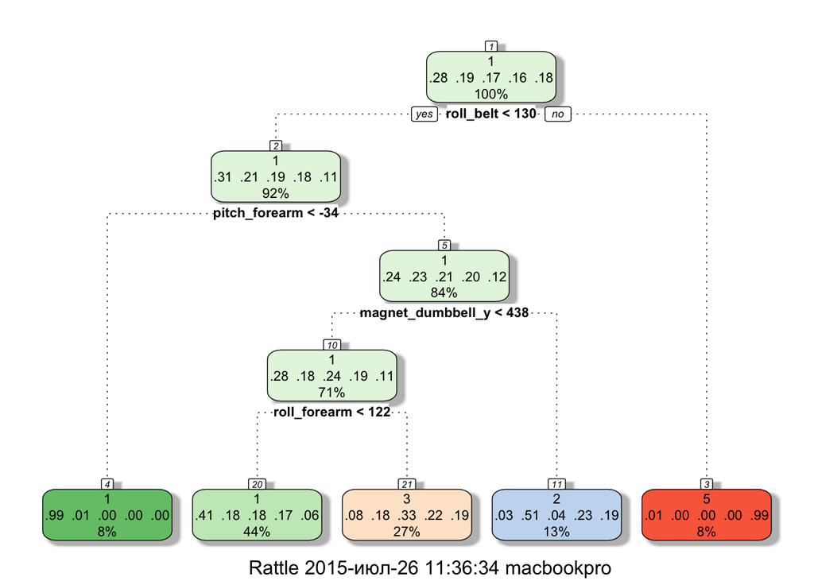

```r
fancyRpartPlot(modelRPART$finalModel)
```

The model looks absolutely surprisingly inefficient, even on the huge data set and it is not appropriate for further usage. But the processing time pretty quick and with more precisely prepared data set it might give better result.

```r
#modelRF <- train(classe ~ ., method = "rf", data = training,  na.action = na.pass)
#print(modelRF$finalModel)
#predRF <- predict(modelRF, subset(testing, select = -classe))
#confusionMatrix(predRF, testing$classe)
#varImpPlot(modelRF$finalModel)
#plot(modelRF$finalModel, log = "y")
```

## Test case prediction

To use trained model on the test case all the data manipulations that were done with the train set should be applied to the test one.

```r
#predTestTry <- predict(modelRF, testTry)
```

## Appendix

Summary of loaded data:

```r
str(train)
```

```
## 'data.frame':    19622 obs. of  160 variables:
##  $ X                       : int  1 2 3 4 5 6 7 8 9 10 ...
##  $ user_name               : Factor w/ 6 levels "adelmo","carlitos",..: 2 2 2 2 2 2 2 2 2 2 ...
##  $ raw_timestamp_part_1    : int  1323084231 1323084231 1323084231 1323084232 1323084232 1323084232 1323084232 1323084232 1323084232 1323084232 ...
##  $ raw_timestamp_part_2    : int  788290 808298 820366 120339 196328 304277 368296 440390 484323 484434 ...
##  $ cvtd_timestamp          : Factor w/ 20 levels "02/12/2011 13:32",..: 9 9 9 9 9 9 9 9 9 9 ...
##  $ new_window              : Factor w/ 2 levels "no","yes": 1 1 1 1 1 1 1 1 1 1 ...
##  $ num_window              : int  11 11 11 12 12 12 12 12 12 12 ...
##  $ roll_belt               : num  1.41 1.41 1.42 1.48 1.48 1.45 1.42 1.42 1.43 1.45 ...
##  $ pitch_belt              : num  8.07 8.07 8.07 8.05 8.07 8.06 8.09 8.13 8.16 8.17 ...
##  $ yaw_belt                : num  -94.4 -94.4 -94.4 -94.4 -94.4 -94.4 -94.4 -94.4 -94.4 -94.4 ...
##  $ total_accel_belt        : int  3 3 3 3 3 3 3 3 3 3 ...
##  $ kurtosis_roll_belt      : Factor w/ 397 levels "","-0.016850",..: 1 1 1 1 1 1 1 1 1 1 ...
##  $ kurtosis_picth_belt     : Factor w/ 317 levels "","-0.021887",..: 1 1 1 1 1 1 1 1 1 1 ...
##  $ kurtosis_yaw_belt       : Factor w/ 2 levels "","#DIV/0!": 1 1 1 1 1 1 1 1 1 1 ...
```

[output cut: 86 more lines]